# Reduccion 16

duraciones triangulares; plazo de 18 semanas; reducción y probabilidad

# Enunciado

Considere el proyecto cuyo cuadro de prelaciones, estimaciones de duración (mínima *a*, más probable *m* y máxima *b*, semanas, distribución triangular), duración tope y coste unitario de reducción (k€/semana) se adjunta; la columna *duration* es la duración esperada. Las actividades con CUR infinito no se pueden acelerar. El contrato exige entregar en **18 semanas**.

1. Con las duraciones esperadas el proyecto dura 20 semanas. Simule 5 000 réplicas y estime la probabilidad de entregar en 18 semanas sin acelerar.

2. Aplique Ackoff-Sasieni para reducir el proyecto hasta 18 semanas con las duraciones esperadas. ¿Qué probabilidad de cumplir el plazo da ahora esa reducción? Compruébelo simulando.

3. Construya la tabla de probabilidad de cumplir el plazo, duración media simulada y coste de reducción en función de las semanas recortadas (de 0 a 8). Use los mismos números aleatorios para todas las filas.

4. ¿Cuántas semanas hay que recortar para tener un 90 % de probabilidad de cumplir? ¿Cuánto cuesta frente a la reducción determinista? ¿Cuánto cuesta cada punto porcentual de probabilidad ganado en cada tramo?

Tabla 1: Cuadro de datos del enunciado

| activity | predecessor | duration | a | m | b | cap_duration | ucr |
| --- | --- | --- | --- | --- | --- | --- | --- |
| A | --- | 3 | 1 | 2 | 6 | 1 | 6.0 |
| B | --- | 8 | 6 | 8 | 10 | 5 | 6.0 |
| C | A | 3 | 1 | 3 | 5 | 3 | inf |
| D | B,C | 7 | 5 | 7 | 9 | 6 | 8.0 |
| E | A | 3 | 1 | 3 | 5 | 2 | 8.0 |
| F | C,E | 5 | 3 | 5 | 7 | 3 | 6.0 |
| G | C | 6 | 4 | 6 | 8 | 6 | inf |
| H | D,F,G | 5 | 3 | 6 | 6 | 2 | 5.0 |

# Resolución

La duración esperada de una triangular es $(a + m + b)/3$; el cuadro la da ya redondeada en *duration*. Con esas duraciones esperadas se calcula el calendario determinista.

Tabla 2: Media de cada triangular frente a la duración esperada del cuadro

| activity | A | B | C | D | E | F | G | H |
| --- | --- | --- | --- | --- | --- | --- | --- | --- |
| (a + m + b)/3 | (1 + 2 + 6)/3 = 3.00 | (6 + 8 + 10)/3 = 8.00 | (1 + 3 + 5)/3 = 3.00 | (5 + 7 + 9)/3 = 7.00 | (1 + 3 + 5)/3 = 3.00 | (3 + 5 + 7)/3 = 5.00 | (4 + 6 + 8)/3 = 6.00 | (3 + 6 + 6)/3 = 5.00 |
| duration | 3 | 8 | 3 | 7 | 3 | 5 | 6 | 5 |

Cálculo de los tiempos tempranos y tardíos de los sucesos y de las holguras totales paso a paso. El primer paso muestra el grafo resuelto; a partir del siguiente se calcula desde el principio (avance con los botones):

[figure not shown]

paso 0 de 26

[figure not shown]

Figura 1: Grafo PERT con las duraciones esperadas y el camino crítico

Tabla 3: Duración esperada de cada ruta

|  | actividades | duración = suma | duración |
| --- | --- | --- | --- |
| Route_1 | A – C – D – H | A(3) + C(3) + D(7) + H(5) = 18 | 18.0 |
| Route_2 | A – C – F – H | A(3) + C(3) + F(5) + H(5) = 16 | 16.0 |
| Route_3 | A – C – G – H | A(3) + C(3) + G(6) + H(5) = 17 | 17.0 |
| Route_4 | A – E – F – H | A(3) + E(3) + F(5) + H(5) = 16 | 16.0 |
| Route_5 | B – D – H | B(8) + D(7) + H(5) = 20 | 20.0 |

## Apartado 1

1. Con las duraciones esperadas el proyecto dura 20 semanas. Simule 5 000 réplicas y estime la probabilidad de entregar en 18 semanas sin acelerar.

Cada réplica sortea una duración por actividad con su triangular; la duración del proyecto es el máximo de las rutas (τ = ‖R·t‖∞). La probabilidad de cumplir es la fracción de réplicas con τ ≤ plazo.

|  | mean | std | q05 | q50 | q95 | min | max |
| --- | --- | --- | --- | --- | --- | --- | --- |
| τ | 20.12 | 1.33 | 17.9 | 20.14 | 22.25 | 15.66 | 24.16 |

Sin acelerar: duración media simulada 20.12 semanas (determinista: 20) y P(τ ≤ 18) = 0.060.

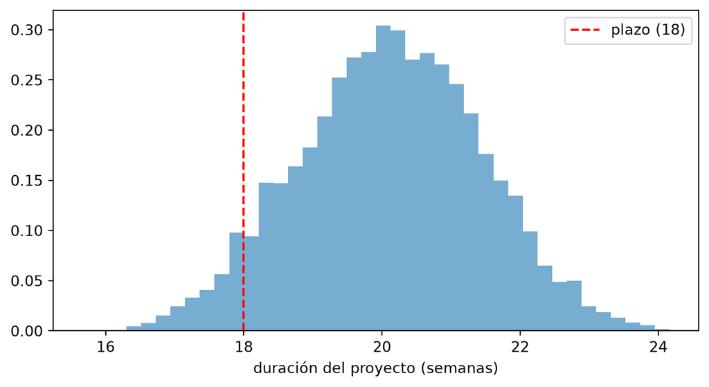

Figura 2: Distribución simulada de la duración sin acelerar

**Respuesta:** sin acelerar, la probabilidad de entregar en 18 semanas es P(τ ≤ 18) ≈ **0.060** (6.0 % de las 5 000 réplicas), con una duración media simulada de 20.12 semanas frente a las 20 deterministas. Para los apartados siguientes se usa `monte_carlo_crashing`, que repite la simulación para cada número de semanas recortadas con los mismos números aleatorios y **redondea cada duración sorteada a semanas enteras** (mínimo 1), como el resto del curso; con ese redondeo, sin recortar sale una media de 20.16 semanas y P(τ ≤ 18) = 0.125. La diferencia con 0.060 se debe al redondeo: una duración simulada de 18.4 semanas, por ejemplo, cuenta como 18 y cumple el plazo.

## Apartado 2

2. Aplique Ackoff-Sasieni para reducir el proyecto hasta 18 semanas con las duraciones esperadas. ¿Qué probabilidad de cumplir el plazo da ahora esa reducción? Compruébelo simulando.

Con las duraciones esperadas el proyecto dura 20 semanas: hay que recortar 20 − 18 = 2 semanas para llegar a 18.

En cada paso del algoritmo de Ackoff-Sasieni se acorta una semana la ruta crítica (o las rutas críticas) eligiendo, entre las actividades críticas con margen, la combinación de menor CUR que reduce *todas* las rutas críticas a la vez.

Tabla 4: Algoritmo de Ackoff-Sasieni con las duraciones esperadas hasta el plazo

[figure not shown]

paso -1 de 2

[figure not shown]

Algoritmo de Ackoff-Sasieni: tabla completa. Pulse «siguiente» para ver cómo se construye.

Tabla 5: Opciones consideradas en cada paso

| paso | duración | rutas críticas | opciones (coste) | elegida | coste del paso |
| --- | --- | --- | --- | --- | --- |
| 1 | 20 | Route_5 | H (5); B (6); D (8) | H | 5.0 |
| 2 | 19 | Route_5 | H (5); B (6); D (8) | H | 5.0 |

- **Pasos 1 y 2** (20 semanas → 18 semanas). Ruta crítica: Route_5 (B – D – H). Opciones que acortan la ruta crítica (CUR en k€/semana): H (5); B (6); D (8). Se elige **H** (la actividad de la ruta crítica con margen y menor CUR), la opción más barata: 5 k€ por semana. Se reducen 2 semanas: se alcanza la reducción pedida. Sobrecoste: 2 × 5 = 10 k€; acumulado: **10 k€**.

**Resultado:** la duración pasa de 20 semanas a 18 semanas con un sobrecoste de 5 + 5 = **10 k€**.

| paso | actividades acortadas | coste del paso | sobrecoste acumulado |
| --- | --- | --- | --- |
| 1 | H | 5.0 | 5.0 |
| 2 | H | 5.0 | 10.0 |

**Respuesta:** reducir las duraciones esperadas hasta 18 semanas exige 2 semanas de reducción y 5 + 5 = 10 k€ (duración determinista 18 semanas); pero, simulando, la probabilidad de cumplir es solo P(τ ≤ 18) = **0.591**: se cumple poco más de la mitad de las veces: la duración esperada queda justo en el plazo y, por el sesgo de fusión de las rutas, muchas réplicas lo superan. Está lejos del 90 % que suele exigirse.

## Apartado 3

3. Construya la tabla de probabilidad de cumplir el plazo, duración media simulada y coste de reducción en función de las semanas recortadas (de 0 a 8). Use los mismos números aleatorios para todas las filas.

Para cada número de semanas recortadas $r$, la tabla da las reducciones que aplica Ackoff-Sasieni (una por paso, separadas por «;»), el coste acumulado, la duración determinista, la media y el percentil 90 simulados y la probabilidad de cumplir, siempre con las mismas 5 000 réplicas de duraciones redondeadas a semanas enteras (a cada réplica se le restan las semanas recortadas a cada actividad, sin bajar de 1 semana).

Tabla 6: Probabilidad de cumplir el plazo según las semanas recortadas

| periodos recortados | actividades acortadas (paso a paso) | duración determinista | coste | τ media | τ P90 | P(τ ≤ plazo) |
| --- | --- | --- | --- | --- | --- | --- |
| 0 | — | 20.0 | 0.0 | 20.158 | 22.0 | 0.125 |
| 1 | H | 19.0 | 5.0 | 19.158 | 21.0 | 0.320 |
| 2 | H; H | 18.0 | 10.0 | 18.158 | 20.0 | 0.591 |
| 3 | H; H; H | 17.0 | 15.0 | 17.187 | 19.0 | 0.828 |
| 4 | H; H; H; B | 16.0 | 21.0 | 16.406 | 18.0 | 0.939 |
| 5 | H; H; H; B; B | 15.0 | 27.0 | 15.818 | 18.0 | 0.966 |
| 6 | H; H; H; B; B; D | 14.0 | 35.0 | 15.118 | 17.0 | 0.989 |
| 7 | H; H; H; B; B; D; A + B | 13.0 | 47.0 | 14.130 | 16.0 | 0.999 |

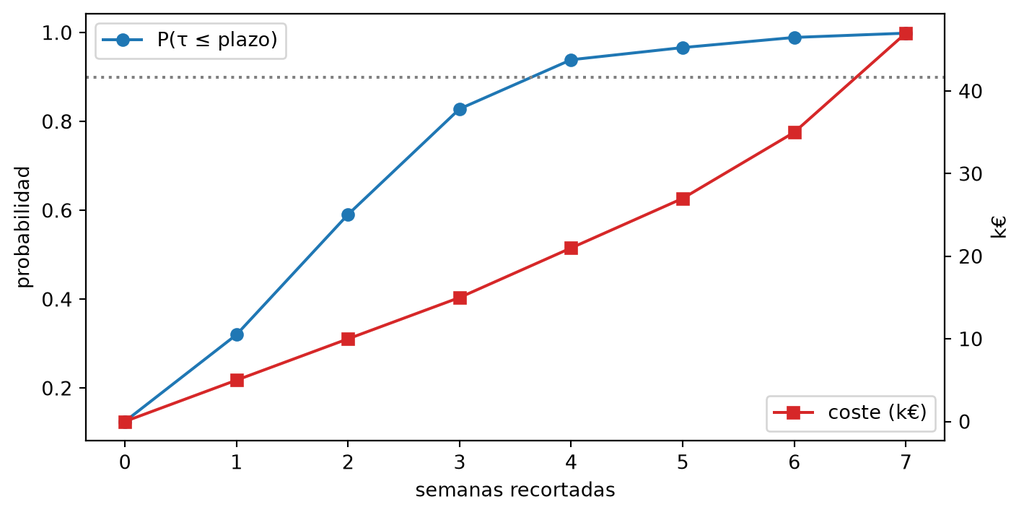

Figura 3: Probabilidad de cumplir y coste de reducción según las semanas recortadas

**Respuesta:** la tabla anterior. Al recortar, la probabilidad de cumplir sube de 0.125 (sin recortar) a 0.999 (7 semanas recortadas, 47 k€) y la duración media simulada baja de 20.16 a 14.13 semanas, siempre algo por encima de la determinista (sesgo de fusión). No se puede recortar más de 7 semanas: después no queda ninguna combinación con margen que acorte todas las rutas críticas (Ackoff-Sasieni se detiene).

## Apartado 4

4. ¿Cuántas semanas hay que recortar para tener un 90 % de probabilidad de cumplir? ¿Cuánto cuesta frente a la reducción determinista? ¿Cuánto cuesta cada punto porcentual de probabilidad ganado en cada tramo?

Coste de cada punto porcentual de probabilidad en cada tramo: lo que cuesta recortar esa semana dividido entre los puntos que gana la probabilidad, $\Delta\text{coste} / (100\,\Delta P)$.

| semanas recortadas | Δcoste (k€) | Δprobabilidad (puntos) | k€ por punto |
| --- | --- | --- | --- |
| 0 → 1 | 5 − 0 = 5 | 32.0 − 12.5 = 19.5 | 5 / 19.5 = 0.26 |
| 1 → 2 | 10 − 5 = 5 | 59.1 − 32.0 = 27.0 | 5 / 27.0 = 0.18 |
| 2 → 3 | 15 − 10 = 5 | 82.8 − 59.1 = 23.8 | 5 / 23.8 = 0.21 |
| 3 → 4 | 21 − 15 = 6 | 93.9 − 82.8 = 11.1 | 6 / 11.1 = 0.54 |
| 4 → 5 | 27 − 21 = 6 | 96.6 − 93.9 = 2.7 | 6 / 2.7 = 2.19 |
| 5 → 6 | 35 − 27 = 8 | 98.9 − 96.6 = 2.3 | 8 / 2.3 = 3.51 |
| 6 → 7 | 47 − 35 = 12 | 99.9 − 98.9 = 1.0 | 12 / 1.0 = 12.50 |

**Respuesta:** para tener al menos un 90 % de probabilidad hay que recortar **4 semanas** (P = 0.939), con un coste de **21 k€**, frente a 2 semanas y 10 k€ de la reducción determinista hasta el plazo (P = 0.591): la diferencia, 11 k€, es lo que cuesta la seguridad. El punto de probabilidad más barato se compra en el tramo 1 → 2 (0.18 k€) y el más caro en el tramo 6 → 7 (12.50 k€): los últimos puntos, cuando la probabilidad ya está cerca de 1, son los más caros.